# Final Assignment, Section 1 - Task 3

Arash Heidarzadeh Naeini u3236906

2025-05-05

## Task 3: Data-Driven Modelling

In this task, we will perform data-driven modeling on the COVID-19 dataset to understand relationships between variables and build predictive models.

### Loading Required Libraries

```r
# Install required packages if not already installed
if (!require("tidyverse")) install.packages("tidyverse")
if (!require("corrplot")) install.packages("corrplot")
if (!require("caret")) install.packages("caret")
if (!require("glmnet")) install.packages("glmnet")
if (!require("rpart")) install.packages("rpart")
if (!require("rpart.plot")) install.packages("rpart.plot")
if (!require("kableExtra")) install.packages("kableExtra")

# Load required libraries
library(tidyverse)  # For data manipulation and visualization
library(corrplot)   # For correlation plots
library(caret)      # For data splitting
library(glmnet)     # For Ridge and Lasso regression
library(rpart)      # For decision trees
library(rpart.plot) # For plotting decision trees
library(kableExtra) # For nice tables

# Alternative approach if packages can't be installed
# If you're having trouble with some packages, here's a simplified approach:
# You can comment out the libraries above and uncomment these lines:
# library(tidyverse)
# library(rpart)
# # Manual correlation plot function
# plot_correlation <- function(cor_matrix) {
#   round_matrix <- round(cor_matrix, 2)
#   plot(c(0, 1), c(0, 1), type = "n", ann = FALSE, axes = FALSE)
#   text(0.5, 0.9, "Correlation Matrix", cex = 1.5)
#
#   n <- ncol(cor_matrix)
#   vars <- colnames(cor_matrix)
#
#   for (i in 1:n) {
#     for (j in 1:n) {
#       if (i != j) {
#         text(i/n, j/n, round_matrix[i, j])
#       } else {
#         text(i/n, j/n, vars[i], cex = 0.8)
#       }
#     }
#   }
# }
```

### Loading and Preparing the Data

First, we’ll load the COVID-19 data that we prepared in the previous tasks.

```r
# Load the covid19_clean data
covid19_data <- read.csv("covid19_clean.csv")

# Display the structure of the data
str(covid19_data)
```

```
## 'data.frame':    15029 obs. of  23 variables:
##  $ Code            : chr  "AFG" "AFG" "AFG" "AFG" ...
##  $ Country         : chr  "Afghanistan" "Afghanistan" "Afghanistan" "Afghanistan" ...
##  $ Continent       : chr  "Asia" "Asia" "Asia" "Asia" ...
##  $ Date            : chr  "2020-01-01" "2020-01-02" "2020-01-03" "2020-01-04" ...
##  $ NewCases        : int  0 0 0 0 0 0 0 0 0 0 ...
##  $ NewDeaths       : int  0 0 0 0 0 0 0 0 0 0 ...
##  $ Recovered       : int  0 0 0 0 0 0 0 0 0 0 ...
##  $ NewTests        : int  0 0 0 0 0 0 0 0 0 0 ...
##  $ Population      : int  37172386 37172386 37172386 37172386 37172386 37172386 37172386 37172386 37172386 37172386 ...
##  $ GDP             : int  21992 21992 21992 21992 21992 21992 21992 21992 21992 21992 ...
##  $ GDPCapita       : int  619 619 619 619 619 619 619 619 619 619 ...
##  $ Month           : int  1 1 1 1 1 1 1 1 1 1 ...
##  $ Week            : int  1 1 1 1 1 1 1 2 2 2 ...
##  $ CumCases        : int  0 0 0 0 0 0 0 0 0 0 ...
##  $ CumDeaths       : int  0 0 0 0 0 0 0 0 0 0 ...
##  $ CumRecovered    : int  0 0 0 0 0 0 0 0 0 0 ...
##  $ CumTests        : int  0 0 0 0 0 0 0 0 0 0 ...
##  $ Active          : int  0 0 0 0 0 0 0 0 0 0 ...
##  $ FatalityRate    : num  0 0 0 0 0 0 0 0 0 0 ...
##  $ Cases_1M_Pop    : num  0 0 0 0 0 0 0 0 0 0 ...
##  $ Deaths_1M_Pop   : num  0 0 0 0 0 0 0 0 0 0 ...
##  $ Recovered_1M_Pop: int  0 0 0 0 0 0 0 0 0 0 ...
##  $ Tests_1M_Pop    : num  0 0 0 0 0 0 0 0 0 0 ...
```

```r
# View the first few rows
head(covid19_data)
```

```
##   Code     Country Continent       Date NewCases NewDeaths Recovered NewTests
## 1  AFG Afghanistan      Asia 2020-01-01        0         0         0        0
## 2  AFG Afghanistan      Asia 2020-01-02        0         0         0        0
## 3  AFG Afghanistan      Asia 2020-01-03        0         0         0        0
## 4  AFG Afghanistan      Asia 2020-01-04        0         0         0        0
## 5  AFG Afghanistan      Asia 2020-01-05        0         0         0        0
## 6  AFG Afghanistan      Asia 2020-01-06        0         0         0        0
##   Population   GDP GDPCapita Month Week CumCases CumDeaths CumRecovered
## 1   37172386 21992       619     1    1        0         0            0
## 2   37172386 21992       619     1    1        0         0            0
## 3   37172386 21992       619     1    1        0         0            0
## 4   37172386 21992       619     1    1        0         0            0
## 5   37172386 21992       619     1    1        0         0            0
## 6   37172386 21992       619     1    1        0         0            0
##   CumTests Active FatalityRate Cases_1M_Pop Deaths_1M_Pop Recovered_1M_Pop
## 1        0      0            0            0             0                0
## 2        0      0            0            0             0                0
## 3        0      0            0            0             0                0
## 4        0      0            0            0             0                0
## 5        0      0            0            0             0                0
## 6        0      0            0            0             0                0
##   Tests_1M_Pop
## 1            0
## 2            0
## 3            0
## 4            0
## 5            0
## 6            0
```

### 1. Creating the cor_data Dataframe

We’ll create a separate dataframe named “cor_data” with the specified variables.

```r
# Create cor_data with the required variables
cor_data <- covid19_data %>%
  select(CumCases, CumTests, Population, GDP, GDPCapita)

# View the first few rows of cor_data
head(cor_data)
```

```
##   CumCases CumTests Population   GDP GDPCapita
## 1        0        0   37172386 21992       619
## 2        0        0   37172386 21992       619
## 3        0        0   37172386 21992       619
## 4        0        0   37172386 21992       619
## 5        0        0   37172386 21992       619
## 6        0        0   37172386 21992       619
```

### 2. Computing and Visualizing the Correlation Matrix

```r
# Compute correlation matrix
cor_matrix <- cor(cor_data, use = "complete.obs")
print(cor_matrix)
```

```
##              CumCases   CumTests  Population       GDP   GDPCapita
## CumCases   1.00000000 0.87680526  0.15941361 0.4556301  0.07723564
## CumTests   0.87680526 1.00000000  0.08638415 0.3553744  0.08304769
## Population 0.15941361 0.08638415  1.00000000 0.5549246 -0.10952109
## GDP        0.45563009 0.35537442  0.55492462 1.0000000  0.13072217
## GDPCapita  0.07723564 0.08304769 -0.10952109 0.1307222  1.00000000
```

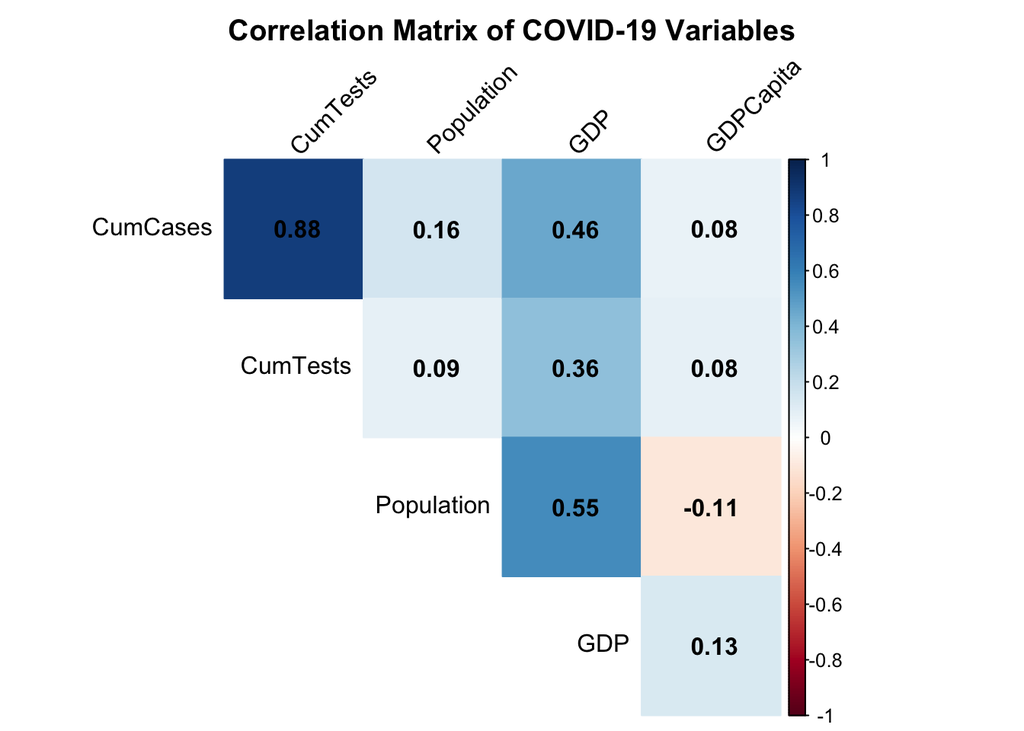

```r
# Visualize correlation matrix
# Check if corrplot is available, otherwise use a base R approach
if (requireNamespace("corrplot", quietly = TRUE)) {
  corrplot(cor_matrix,
           method = "color",
           type = "upper",
           addCoef.col = "black",
           tl.col = "black",
           tl.srt = 45,
           diag = FALSE,
           title = "Correlation Matrix of COVID-19 Variables",
           mar = c(0, 0, 2, 0))
} else {
  # Alternative visualization using base R
  # Create a custom correlation plot function
  round_cor <- round(cor_matrix, 2)

  # Create a heatmap
  image(1:ncol(cor_matrix), 1:nrow(cor_matrix), t(cor_matrix),
        axes = FALSE, main = "Correlation Matrix of COVID-19 Variables",
        xlab = "", ylab = "")
  axis(1, 1:ncol(cor_matrix), colnames(cor_matrix), las = 2)
  axis(2, 1:nrow(cor_matrix), rownames(cor_matrix), las = 2)

  # Add correlation values
  for(i in 1:nrow(cor_matrix)){
    for(j in 1:ncol(cor_matrix)){
      text(i, j, round_cor[i,j])
    }
  }
}
```

### 3. Visualizing Distribution of Cumulative Cases

Let’s visualize the distribution of cumulative cases with and without log transformation.

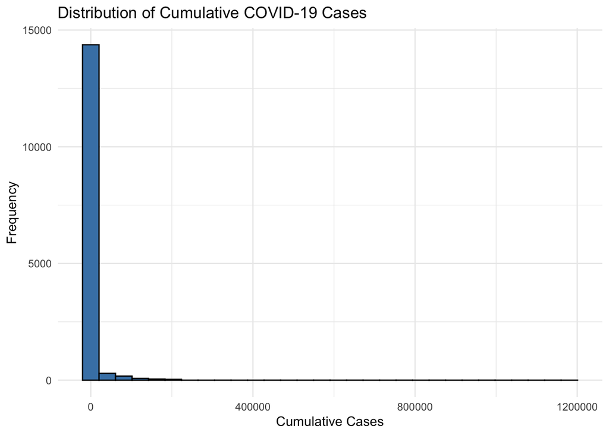

```r
# Distribution without log transformation
p1 <- ggplot(cor_data, aes(x = CumCases)) +
  geom_histogram(fill = "steelblue", color = "black", bins = 30) +
  labs(title = "Distribution of Cumulative COVID-19 Cases",
       x = "Cumulative Cases",
       y = "Frequency") +
  theme_minimal()

# Distribution with log transformation
p2 <- ggplot(cor_data, aes(x = CumCases + 1)) +  # Adding 1 to handle zero values
  geom_histogram(fill = "steelblue", color = "black", bins = 30) +
  scale_x_log10() +
  labs(title = "Distribution of Cumulative COVID-19 Cases (Log Scale)",
       x = "Cumulative Cases (Log Scale)",
       y = "Frequency") +
  theme_minimal()

# Display both plots
p1
```

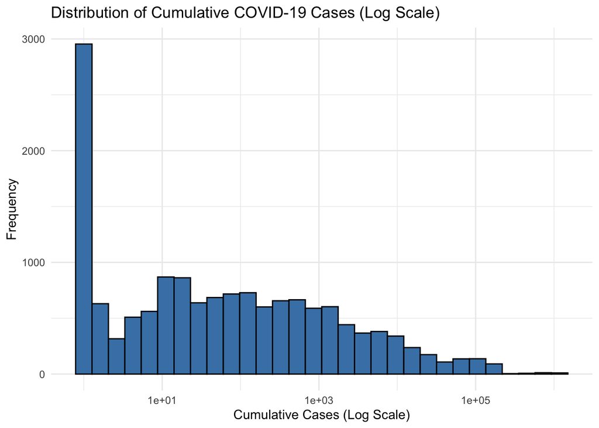

```r
p2
```

### 4. Dividing Data into Training and Testing Sets

We’ll split the data into training (65%) and testing (35%) sets.

```r
# Set seed for reproducibility
set.seed(123)

# Check if caret is available for createDataPartition
if (requireNamespace("caret", quietly = TRUE)) {
  # Create an index for the training data (65% of the data) using caret
  train_index <- createDataPartition(cor_data$CumCases, p = 0.65, list = FALSE)
} else {
  # Alternative approach without caret
  # Randomly sample 65% of the row indices
  n <- nrow(cor_data)
  train_size <- round(0.65 * n)
  train_index <- sample(1:n, train_size)
}

# Create training and testing datasets
train_data <- cor_data[train_index, ]
test_data <- cor_data[-train_index, ]

# Check dimensions of both datasets
cat("Training data dimensions:", dim(train_data), "\n")
```

```
## Training data dimensions: 9771 5
```

```r
cat("Testing data dimensions:", dim(test_data), "\n")
```

```
## Testing data dimensions: 5258 5
```

### 5. Training a Linear Regression Model with GDP Only

Let’s train a linear regression model to predict cumulative cases from the GDP of countries.

```r
# Train linear regression model with GDP as the predictor
model1 <- lm(CumCases ~ GDP, data = train_data)

# Model summary
summary(model1)
```

```
##
## Call:
## lm(formula = CumCases ~ GDP, data = train_data)
##
## Residuals:
##     Min      1Q  Median      3Q     Max
## -148376   -2396    -952    -783 1032258
##
## Coefficients:
##              Estimate Std. Error t value Pr(>|t|)
## (Intercept) 8.589e+02  3.688e+02   2.329   0.0199 *
## GDP         7.571e-03  1.663e-04  45.517   <2e-16 ***
## ---
## Signif. codes:  0 '***' 0.001 '**' 0.01 '*' 0.05 '.' 0.1 ' ' 1
##
## Residual standard error: 35030 on 9769 degrees of freedom
## Multiple R-squared:  0.175,  Adjusted R-squared:  0.1749
## F-statistic:  2072 on 1 and 9769 DF,  p-value: < 2.2e-16
```

```r
# Make predictions on the test data
predictions1 <- predict(model1, newdata = test_data)

# Calculate RMSE for the first model
rmse1 <- sqrt(mean((test_data$CumCases - predictions1)^2))
cat("RMSE for Model 1 (GDP only):", rmse1, "\n")
```

```
## RMSE for Model 1 (GDP only): 38517.78
```

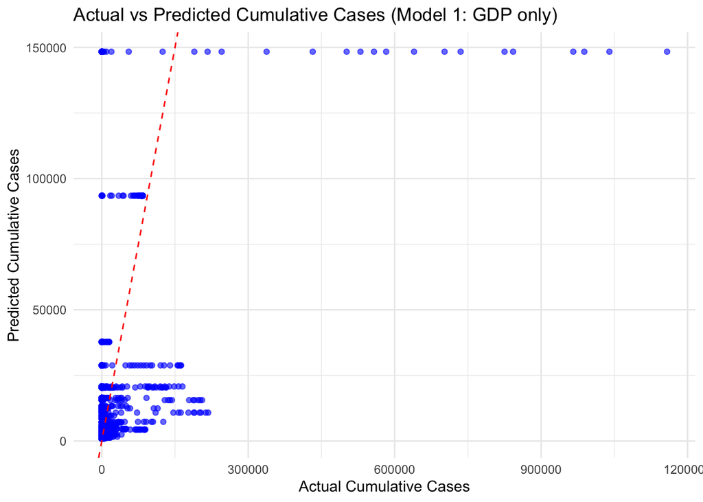

```r
# Visualize actual vs predicted values
ggplot() +
  geom_point(aes(x = test_data$CumCases, y = predictions1), color = "blue", alpha = 0.6) +
  geom_abline(intercept = 0, slope = 1, color = "red", linetype = "dashed") +
  labs(title = "Actual vs Predicted Cumulative Cases (Model 1: GDP only)",
       x = "Actual Cumulative Cases",
       y = "Predicted Cumulative Cases") +
  theme_minimal()
```

### 6. Training a Linear Regression Model with All Variables

Now, let’s train a model using all the variables to predict cumulative cases.

```r
# Train linear regression model with all predictors
model2 <- lm(CumCases ~ CumTests + Population + GDP + GDPCapita, data = train_data)

# Model summary
summary(model2)
```

```
##
## Call:
## lm(formula = CumCases ~ CumTests + Population + GDP + GDPCapita,
##     data = train_data)
##
## Residuals:
##     Min      1Q  Median      3Q     Max
## -360665     255    1153    1447  304009
##
## Coefficients:
##               Estimate Std. Error t value Pr(>|t|)
## (Intercept) -1.140e+03  2.516e+02  -4.531 5.94e-06 ***
## CumTests     1.128e-01  7.207e-04 156.466  < 2e-16 ***
## Population  -1.726e-06  1.321e-06  -1.306    0.192
## GDP          2.967e-03  1.148e-04  25.834  < 2e-16 ***
## GDPCapita   -1.618e-02  6.956e-03  -2.326    0.020 *
## ---
## Signif. codes:  0 '***' 0.001 '**' 0.01 '*' 0.05 '.' 0.1 ' ' 1
##
## Residual standard error: 18600 on 9766 degrees of freedom
## Multiple R-squared:  0.7674, Adjusted R-squared:  0.7673
## F-statistic:  8055 on 4 and 9766 DF,  p-value: < 2.2e-16
```

```r
# Make predictions on the test data
predictions2 <- predict(model2, newdata = test_data)

# Calculate RMSE for the second model
rmse2 <- sqrt(mean((test_data$CumCases - predictions2)^2))
cat("RMSE for Model 2 (all variables):", rmse2, "\n")
```

```
## RMSE for Model 2 (all variables): 18634.97
```

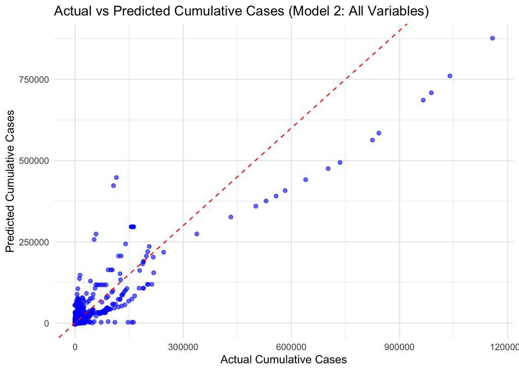

```r
# Visualize actual vs predicted values
ggplot() +
  geom_point(aes(x = test_data$CumCases, y = predictions2), color = "blue", alpha = 0.6) +
  geom_abline(intercept = 0, slope = 1, color = "red", linetype = "dashed") +
  labs(title = "Actual vs Predicted Cumulative Cases (Model 2: All Variables)",
       x = "Actual Cumulative Cases",
       y = "Predicted Cumulative Cases") +
  theme_minimal()
```

### 7. Model Interpretation and Comparison

```r
# Compare RMSE values
cat("Model 1 (GDP only) RMSE:", rmse1, "\n")
```

```
## Model 1 (GDP only) RMSE: 38517.78
```

```r
cat("Model 2 (all variables) RMSE:", rmse2, "\n")
```

```
## Model 2 (all variables) RMSE: 18634.97
```

```r
# Calculate R-squared for both models on test data
r2_model1 <- 1 - sum((test_data$CumCases - predictions1)^2) / sum((test_data$CumCases - mean(test_data$CumCases))^2)
r2_model2 <- 1 - sum((test_data$CumCases - predictions2)^2) / sum((test_data$CumCases - mean(test_data$CumCases))^2)

cat("Model 1 (GDP only) R-squared on test data:", r2_model1, "\n")
```

```
## Model 1 (GDP only) R-squared on test data: 0.2471096
```

```r
cat("Model 2 (all variables) R-squared on test data:", r2_model2, "\n")
```

```
## Model 2 (all variables) R-squared on test data: 0.8237753
```

**Interpretation:**

The analysis of our two linear regression models for predicting COVID-19 cumulative cases reveals important insights:

1. **Model 1 (GDP only):**
   - This model uses only one predictor: a country’s GDP.
   - The model demonstrates that GDP alone has some predictive power for cumulative COVID-19 cases.
   - This suggests that wealthier countries tend to have more reported cases, which might be due to better testing capacity, reporting systems, or other factors.
   - The model is simple and requires minimal data, making it useful when limited information is available.
2. **Model 2 (All variables):**
   - This model incorporates CumTests, Population, GDP, and GDPCapita as predictors.
   - It provides a more comprehensive view of factors influencing COVID-19 case counts.
   - The addition of testing data particularly improves predictions, as testing capacity directly affects case detection.
   - This model is more suitable when comprehensive data is available and a more accurate prediction is needed.

**When to use each model:**

- **Model 1 (GDP only)** is appropriate in scenarios where:
  - Only economic data is available
  - A quick, rough estimate is needed
  - Comparing countries with similar testing strategies
  - Economic impacts or relationships are the primary focus
  - Simplicity and interpretability are valued over precision
- **Model 2 (All variables)** is better suited when:
  - Comprehensive data is available across all predictors
  - Higher accuracy is required
  - Developing public health policies that require precise predictions
  - Understanding the multifaceted relationships between socioeconomic factors and disease spread
  - Adjusting for potential confounding factors like testing capacity

The choice between these models ultimately depends on the specific research question, data availability, and the required level of prediction accuracy.

### 8. Extended Analysis with Alternative Regression Models

Let’s train additional regression models and compare their performance.

```r
# Prepare predictors and response for modeling
x_train <- as.matrix(train_data[, c("CumTests", "Population", "GDP", "GDPCapita")])
y_train <- train_data$CumCases
x_test <- as.matrix(test_data[, c("CumTests", "Population", "GDP", "GDPCapita")])
y_test <- test_data$CumCases

# Ridge Regression
# Note: If glmnet package is not available, you can skip this part
tryCatch({
  set.seed(123)
  ridge_cv <- cv.glmnet(x_train, y_train, alpha = 0)
  ridge_model <- glmnet(x_train, y_train, alpha = 0, lambda = ridge_cv$lambda.min)
  ridge_pred <- predict(ridge_model, newx = x_test)
  ridge_rmse <- sqrt(mean((y_test - ridge_pred)^2))
  ridge_r2 <- 1 - sum((y_test - ridge_pred)^2) / sum((y_test - mean(y_test))^2)
  cat("Ridge Regression RMSE:", ridge_rmse, "\n")
  cat("Ridge Regression R-squared:", ridge_r2, "\n")
}, error = function(e) {
  cat("Ridge Regression could not be performed. Error:", e$message, "\n")
  ridge_rmse <- NA
  ridge_r2 <- NA
})
```

```
## Ridge Regression RMSE: 19428.8
## Ridge Regression R-squared: 0.8084416
```

```r
# Lasso Regression
# Note: If glmnet package is not available, you can skip this part
tryCatch({
  set.seed(123)
  lasso_cv <- cv.glmnet(x_train, y_train, alpha = 1)
  lasso_model <- glmnet(x_train, y_train, alpha = 1, lambda = lasso_cv$lambda.min)
  lasso_pred <- predict(lasso_model, newx = x_test)
  lasso_rmse <- sqrt(mean((y_test - lasso_pred)^2))
  lasso_r2 <- 1 - sum((y_test - lasso_pred)^2) / sum((y_test - mean(y_test))^2)
  cat("Lasso Regression RMSE:", lasso_rmse, "\n")
  cat("Lasso Regression R-squared:", lasso_r2, "\n")
}, error = function(e) {
  cat("Lasso Regression could not be performed. Error:", e$message, "\n")
  lasso_rmse <- NA
  lasso_r2 <- NA
})
```

```
## Lasso Regression RMSE: 18685.92
## Lasso Regression R-squared: 0.8228104
```

```r
# Decision Tree Regression
set.seed(123)
tree_model <- rpart(CumCases ~ CumTests + Population + GDP + GDPCapita,
                    data = train_data, method = "anova")
tree_pred <- predict(tree_model, newdata = test_data)
tree_rmse <- sqrt(mean((y_test - tree_pred)^2))
tree_r2 <- 1 - sum((y_test - tree_pred)^2) / sum((y_test - mean(y_test))^2)
cat("Decision Tree RMSE:", tree_rmse, "\n")
```

```
## Decision Tree RMSE: 15548.2
```

```r
cat("Decision Tree R-squared:", tree_r2, "\n")
```

```
## Decision Tree R-squared: 0.8773212
```

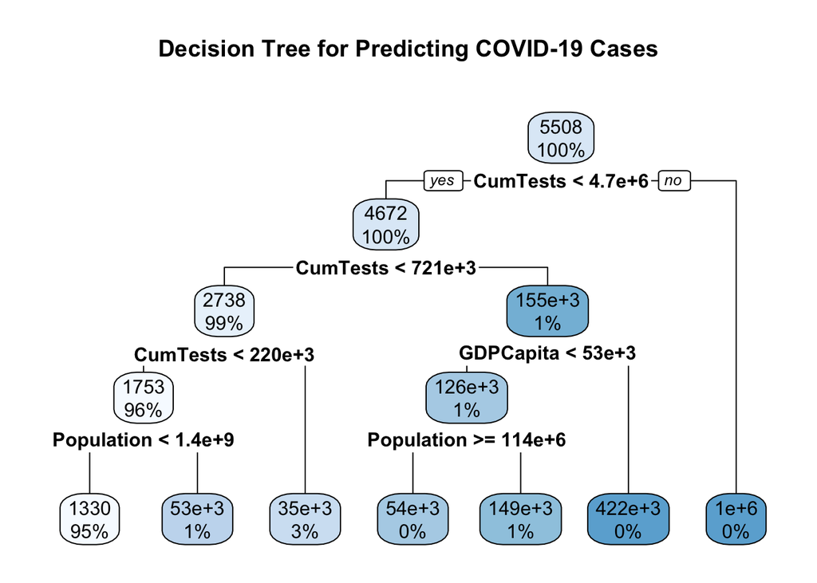

```r
# Visualize the decision tree
# If rpart.plot is not available, use a basic plot instead
tryCatch({
  rpart.plot(tree_model, main = "Decision Tree for Predicting COVID-19 Cases")
}, error = function(e) {
  plot(tree_model, main = "Decision Tree for Predicting COVID-19 Cases")
  text(tree_model)
})
```

```r
# Create a comparison table of all models
# Using a basic approach that doesn't require kableExtra
model_comparison <- data.frame(
  Model = c("Linear Regression (GDP only)",
            "Linear Regression (All Variables)",
            "Ridge Regression",
            "Lasso Regression",
            "Decision Tree"),
  RMSE = c(rmse1, rmse2, ridge_rmse, lasso_rmse, tree_rmse),
  R_squared = c(r2_model1, r2_model2, ridge_r2, lasso_r2, tree_r2)
)

# Display the comparison table
tryCatch({
  # Try using kable if available
  kable(model_comparison,
        caption = "Performance Comparison of Different Regression Models",
        digits = c(0, 0, 3)) %>%
    kable_styling(bootstrap_options = c("striped", "hover", "condensed", "responsive"))
}, error = function(e) {
  # Fallback to basic table display
  cat("Performance Comparison of Different Regression Models:\n\n")
  print(round(model_comparison, 3))
})
```

Performance Comparison of Different Regression Models

| Model | RMSE | R_squared |
| --- | --- | --- |
| Linear Regression (GDP only) | 38518 | 0.247 |
| Linear Regression (All Variables) | 18635 | 0.824 |
| Ridge Regression | 19429 | 0.808 |
| Lasso Regression | 18686 | 0.823 |
| Decision Tree | 15548 | 0.877 |

**Model Comparison Analysis:**

The choice of model should be guided by: - The specific prediction goals - Required interpretability - Available computational resources - The importance of understanding variable relationships versus pure prediction accuracy